# ANALISIS EXPLORATORIO DE DATOS CASOS POSITIVOS COVID 19 EN ATLANTICO

### Estudiantes:

- Juan Esteban Garcia Gomez
- Luis Esteban Mariño

## Introduccion:

Se creará una nueva variable que permita calcular el tiempo de recuperación de los pacientes recuperados y el tiempo transcurrido hasta el fallecimiento en los casos de muerte. Esto facilitará comprender mejor el comportamiento y la evolución de la enfermedad en la población estudiada.

Adicionalmente con estos datos podremos identificar :

- Cuáles son los casos más comunes de contagio de COVID-19 en el departamento del Atlántico.
- Analizar en qué tipo de población se concentraron la mayor cantidad de muertes.
- Observar los tiempos en los que se registraron mas casos positivos de Covid 19.

## Descripcion de Variables:

**fecha reporte web** : Fecha en que se diligencio el caso en esta web.

**ID de caso** : Numero del caso positivo de covid 19.

**Fecha de Notificacion** : Fecha en que se reporto el resultado positivo de covid 19 del paciente.

**Código DIVIPOLA departamento** : Codigo del Departamento donde el paciente recibio el resultado positivo de Covid 19.

**Nombre departamento** : Nombre del departamento donde el paciente recibio el resultado positivo de Covid 19

**Codigo DIVIPOLA municipio** : Codigo del Municipio en el que el paciente se realizo el examen de covid 19

**Nombre municipio** : Nombre del municipio donde el contagiado por covid 19 se realizo la prueba.

**Edad** : Edad del contagiado.

**Unidad de medida de edad** : Unidad de medida de edad del contagiado ( años : 1 , meses : 2 , dias : 3)

**Sexo**: Sexo del caso positivo por covid 19.

**Tipo de contagio**: Forma en que fue contagiado por covid 19.

**Ubicacion del caso**: Lugar donde transcurrio el contagiado por covid 19.

**Estado** : Estado de salud del paciente.

**Codigo ISO del país**: Codigo ISO del pais de origen del paciente.

**Nombre del Pais**: Pais de origen del contagiado por Covid 19.

**Recuperado**: Estado final del paciente.

**Fecha de inicio de sintomas** : Dia en el que tuvo los primeros sintomas el paciente.

**Fecha de muerte** : Dia en el que murio el paciente.

**Fecha de diagnostico** : Dia en el que se recibio el resultado positivo por Covid 19.

**Fecha de recuperacion** : Dia en el que se recupero el paciente del covid 19.

**Tipo de recuperacion** : Forma en que se confirma el paciente como recuperado.

**Pertenencia Etnica** : Etnia a la que pertenece el contagiado por Covid 19.(Indígena :1 , ROM: 2 , Raizal: 3, Palenquero :4 , Negro: 5 , Otro: 6).

**Nombre del grupo Etnico**: Nombre del grupo etnico que pertenece el paciente( en caso haga parte de uno).

```python
import pandas as pd
import matplotlib.pyplot as plt
import seaborn as sns
import numpy as np

df = pd.read_csv("C:/Users/Juanes Garcia Gomez/Documents/EDA#1/Casos_positivos_de_COVID-19_en_atlantico._20260221 (2).csv", sep=";")

df.head()
```

```
C:\Users\Juanes Garcia Gomez\AppData\Local\Temp\ipykernel_18940\3569439215.py:6: DtypeWarning: Columns (0,1,2,4,6,9,10,11,12,14,15,16,17,18,19,20,22) have mixed types. Specify dtype option on import or set low_memory=False.
  df = pd.read_csv("C:/Users/Juanes Garcia Gomez/Documents/EDA#1/Casos_positivos_de_COVID-19_en_atlantico._20260221 (2).csv", sep=";")
```

|  | fecha reporte web | ID de caso | Fecha de notificacion | Codigo DIVIPOLA departamento | Nombre departamento | Codigo DIVIPOLA municipio | Nombre municipio | Edad | Unidad de medida de edad | Sexo | ... | Codigo ISO del país | Nombre del Pais | Recuperado | Fecha de inicio de sintomas | Fecha de muerte | Fecha de diagnostico | Fecha de recuperacion | Tipo de recuperacion | Pertenencia Etnica | Nombre del grupo Etnico |
| --- | --- | --- | --- | --- | --- | --- | --- | --- | --- | --- | --- | --- | --- | --- | --- | --- | --- | --- | --- | --- | --- |
| 0 | 16/03/2020 0:00 | 59 | 14/03/2020 0:00 | 8.001 | BARRANQUILLA | 8.001 | BARRANQUILLA | 20.0 | 1.0 | M | ... | 724.0 | ESPAÑA | Recuperado | 13/03/2020 0:00 | NaN | 16/03/2020 0:00 | 27/03/2020 0:00 | PCR | 6.0 | NaN |
| 1 | 16/03/2020 0:00 | 61 | 16/03/2020 0:00 | 8.001 | BARRANQUILLA | 8.001 | BARRANQUILLA | 21.0 | 1.0 | M | ... | 724.0 | ESPAÑA | Recuperado | 10/03/2020 0:00 | NaN | 16/03/2020 0:00 | 24/03/2020 0:00 | PCR | 6.0 | NaN |
| 2 | 24/03/2020 0:00 | 324 | 16/03/2020 0:00 | 8.001 | BARRANQUILLA | 8.001 | BARRANQUILLA | 57.0 | 1.0 | M | ... | 591.0 | PANAMA | Recuperado | 16/03/2020 0:00 | NaN | 24/03/2020 0:00 | 30/03/2020 0:00 | PCR | 6.0 | NaN |
| 3 | 19/03/2020 0:00 | 127 | 18/03/2020 0:00 | 8.001 | BARRANQUILLA | 8.001 | BARRANQUILLA | 30.0 | 1.0 | F | ... | NaN | NaN | Recuperado | 16/03/2020 0:00 | NaN | 19/03/2020 0:00 | 29/03/2020 0:00 | PCR | 6.0 | NaN |
| 4 | 19/03/2020 0:00 | 126 | 18/03/2020 0:00 | 8.001 | BARRANQUILLA | 8.001 | BARRANQUILLA | 52.0 | 1.0 | F | ... | 840.0 | ESTADOS UNIDOS DE AMÉRICA | Recuperado | 6/03/2020 0:00 | NaN | 19/03/2020 0:00 | 31/03/2020 0:00 | PCR | 5.0 | NaN |

5 rows × 23 columns

```python
df = df.dropna(how="all")
df.shape
```

```
(419061, 23)
```

## Creacion variable Dias de recuperacion

Tomamos la diferencia de dias entre la fecha de primeros sintomas y fecha de recuperacion

```python
df["Fecha de inicio de sintomas"] = pd.to_datetime(df['Fecha de inicio de sintomas'], dayfirst=True)
df["Fecha de recuperacion"] = pd.to_datetime(df["Fecha de recuperacion"], dayfirst=True)

df['Dias de recuperacion'] = (
    df['Fecha de recuperacion'] - df['Fecha de inicio de sintomas']
).dt.days
df["Dias de recuperacion"].describe()
```

```
count    403408.000000
mean         23.225186
std          28.576806
min           2.000000
25%          14.000000
50%          15.000000
75%          21.000000
max         386.000000
Name: Dias de recuperacion, dtype: float64
```

## Creacion Variable Dias hasta fallecimiento

Esta variable fue creada para calcular el número de días transcurridos desde la fecha de inicio de síntomas hasta la fecha de fallecimiento, con el fin de analizar el tiempo de evolución del covid 19 en los casos graves.

```python
df["Fecha de muerte"] = pd.to_datetime(df["Fecha de muerte"], dayfirst=True)
df["dias hasta fallecimiento"] = (df["Fecha de muerte"] - df["Fecha de inicio de sintomas"]).dt.days
df["dias hasta fallecimiento"].describe()
```

```
count    13130.000000
mean        42.410282
std         74.911648
min          0.000000
25%         11.000000
50%         19.000000
75%         31.000000
max        543.000000
Name: dias hasta fallecimiento, dtype: float64
```

## Revision N/A

```python
resumen_na = pd.DataFrame({
    'Total NA': df.isna().sum(),
    'PORCENTAJE NA': df.isna().mean() * 100
}).sort_values(by='PORCENTAJE NA', ascending=False)

resumen_na
```

|  | Total NA | PORCENTAJE NA |
| --- | --- | --- |
| Nombre del Pais | 418987 | 99.982341 |
| Codigo ISO del país | 418987 | 99.982341 |
| Nombre del grupo Etnico | 412797 | 98.505230 |
| dias hasta fallecimiento | 405931 | 96.866805 |
| Fecha de muerte | 405922 | 96.864657 |
| Dias de recuperacion | 15653 | 3.735256 |
| Tipo de recuperacion | 12747 | 3.041801 |
| Fecha de recuperacion | 12744 | 3.041085 |
| Fecha de inicio de sintomas | 2916 | 0.695841 |
| Ubicacion del caso | 2882 | 0.687728 |
| Estado | 2882 | 0.687728 |
| Recuperado | 2428 | 0.579391 |
| Fecha de diagnostico | 1144 | 0.272991 |
| Pertenencia Etnica | 40 | 0.009545 |
| Unidad de medida de edad | 0 | 0.000000 |
| Fecha de notificacion | 0 | 0.000000 |
| ID de caso | 0 | 0.000000 |
| fecha reporte web | 0 | 0.000000 |
| Edad | 0 | 0.000000 |
| Nombre municipio | 0 | 0.000000 |
| Codigo DIVIPOLA municipio | 0 | 0.000000 |
| Nombre departamento | 0 | 0.000000 |
| Codigo DIVIPOLA departamento | 0 | 0.000000 |
| Tipo de contagio | 0 | 0.000000 |
| Sexo | 0 | 0.000000 |

Teniendo en cuenta la base de datos y los datos N/A, los datos N/A en la variable "Nombre del Pais" son de Colombia por lo que se van a reemplazar por "Colombia. Por otra parte, por la poca utilidad de la variable Codigo ISO del país y su gran porcentaje de N/A, se va a borrar la columna.

```python
df["Nombre del Pais"] = df["Nombre del Pais"].fillna("Colombia")
```

```python
df = df.drop(columns=["Codigo ISO del país"])
```

Adicionalmente, al analizar los valores faltantes en la variable “Recuperado”, se observa que estos corresponden a registros que presentan una fecha de muerte, lo que indica que se trata de personas fallecidas.

```python
df["Recuperado"] = df["Recuperado"].fillna("Fallecido")
```

```python
df["Recuperado"] = df["Recuperado"].replace("fallecido", "Fallecido")
df["Recuperado"].unique()
```

```
array(['Recuperado', 'Fallecido', 'Activo'], dtype=object)
```

```python
df["Nombre municipio"] = df["Nombre municipio"].str.lower().replace({
    "puerto colombia": "Puerto Colombia",
})
df["Nombre municipio"].unique()
```

```
array(['barranquilla', 'soledad', 'galapa', 'santo tomas', 'ponedera',
       'polo nuevo', 'Puerto Colombia', 'baranoa', 'malambo',
       'palmar de varela', 'sabanagrande', 'manati', 'sabanalarga',
       'santa lucia', 'repelon', 'candelaria', 'usiacuri',
       'juan de acosta', 'luruaco', 'campo de la cruz', 'tubara', 'piojo',
       'suan'], dtype=object)
```

## Conversion Variable edad

La variable "Unidad de medida de edad" indica si la edad del paciente está expresada en años, meses o días. En este caso se va a unificar la información y se realizará la conversión de la edad de todos los pacientes a años.

```python
df["Edad_años"] = df["Edad"]

df.loc[df["Unidad de medida de edad"] == 2, "Edad_años"] = (
    df.loc[df["Unidad de medida de edad"] == 2, "Edad"] / 12
)

df.loc[df["Unidad de medida de edad"] == 3, "Edad_años"] = (
    df.loc[df["Unidad de medida de edad"] == 3, "Edad"] / 365
)
```

## Resumen Variables

```python
print("DIMENSIONES:", df.shape)
print("INFORMACION")
print(df.info())

print("RESUMEN ESTADISTICO")
display(df.describe(include="all").T.head(25))
```

```
DIMENSIONES: (419061, 25)
INFORMACION
<class 'pandas.core.frame.DataFrame'>
Index: 419061 entries, 0 to 419060
Data columns (total 25 columns):
 #   Column                        Non-Null Count   Dtype
---  ------                        --------------   -----
 0   fecha reporte web             419061 non-null  object
 1   ID de caso                    419061 non-null  object
 2   Fecha de notificacion         419061 non-null  object
 3   Codigo DIVIPOLA departamento  419061 non-null  float64
 4   Nombre departamento           419061 non-null  object
 5   Codigo DIVIPOLA municipio     419061 non-null  float64
 6   Nombre municipio              419061 non-null  object
 7   Edad                          419061 non-null  float64
 8   Unidad de medida de edad      419061 non-null  float64
 9   Sexo                          419061 non-null  object
 10  Tipo de contagio              419061 non-null  object
 11  Ubicacion del caso            416179 non-null  object
 12  Estado                        416179 non-null  object
 13  Nombre del Pais               419061 non-null  object
 14  Recuperado                    419061 non-null  object
 15  Fecha de inicio de sintomas   416145 non-null  datetime64[ns]
 16  Fecha de muerte               13139 non-null   datetime64[ns]
 17  Fecha de diagnostico          417917 non-null  object
 18  Fecha de recuperacion         406317 non-null  datetime64[ns]
 19  Tipo de recuperacion          406314 non-null  object
 20  Pertenencia Etnica            419021 non-null  float64
 21  Nombre del grupo Etnico       6264 non-null    object
 22  Dias de recuperacion          403408 non-null  float64
 23  dias hasta fallecimiento      13130 non-null   float64
 24  Edad_años                     419061 non-null  float64
dtypes: datetime64[ns](3), float64(8), object(14)
memory usage: 83.1+ MB
None
RESUMEN ESTADISTICO
```

|  | count | unique | top | freq | mean | min | 25% | 50% | 75% | max | std |
| --- | --- | --- | --- | --- | --- | --- | --- | --- | --- | --- | --- |
| fecha reporte web | 419061 | 857 | 12/04/2021 0:00 | 3948 | NaN | NaN | NaN | NaN | NaN | NaN | NaN |
| ID de caso | 419061 | 419061 | 6.390.830 | 1 | NaN | NaN | NaN | NaN | NaN | NaN | NaN |
| Fecha de notificacion | 419061 | 1318 | 7/04/2021 0:00 | 3975 | NaN | NaN | NaN | NaN | NaN | NaN | NaN |
| Codigo DIVIPOLA departamento | 419061.0 | NaN | NaN | NaN | 8.000663 | 8.0 | 8.0 | 8.001 | 8.001 | 8.001 | 0.000473 |
| Nombre departamento | 419061 | 2 | BARRANQUILLA | 277989 | NaN | NaN | NaN | NaN | NaN | NaN | NaN |
| Codigo DIVIPOLA municipio | 419061.0 | NaN | NaN | NaN | 8.205152 | 8.001 | 8.001 | 8.001 | 8.52 | 8.849 | 0.310703 |
| Nombre municipio | 419061 | 23 | barranquilla | 277989 | NaN | NaN | NaN | NaN | NaN | NaN | NaN |
| Edad | 419061.0 | NaN | NaN | NaN | 40.276058 | 1.0 | 26.0 | 38.0 | 54.0 | 113.0 | 19.470204 |
| Unidad de medida de edad | 419061.0 | NaN | NaN | NaN | 1.005505 | 1.0 | 1.0 | 1.0 | 1.0 | 3.0 | 0.080035 |
| Sexo | 419061 | 2 | F | 222971 | NaN | NaN | NaN | NaN | NaN | NaN | NaN |
| Tipo de contagio | 419061 | 3 | Comunitaria | 288243 | NaN | NaN | NaN | NaN | NaN | NaN | NaN |
| Ubicacion del caso | 416179 | 6 | Casa | 402582 | NaN | NaN | NaN | NaN | NaN | NaN | NaN |
| Estado | 416179 | 6 | Leve | 400808 | NaN | NaN | NaN | NaN | NaN | NaN | NaN |
| Nombre del Pais | 419061 | 15 | Colombia | 418987 | NaN | NaN | NaN | NaN | NaN | NaN | NaN |
| Recuperado | 419061 | 3 | Recuperado | 406314 | NaN | NaN | NaN | NaN | NaN | NaN | NaN |
| Fecha de inicio de sintomas | 416145 | NaN | NaN | NaN | 2021-04-26 11:18:43.405543424 | 2020-03-03 00:00:00 | 2021-01-05 00:00:00 | 2021-04-09 00:00:00 | 2021-08-20 00:00:00 | 2024-01-14 00:00:00 | NaN |
| Fecha de muerte | 13139 | NaN | NaN | NaN | 2021-04-01 20:54:33.673795840 | 2020-03-27 00:00:00 | 2020-09-07 00:00:00 | 2021-04-14 00:00:00 | 2021-05-29 00:00:00 | 2023-11-19 00:00:00 | NaN |
| Fecha de diagnostico | 417917 | 1317 | 7/04/2021 0:00 | 4382 | NaN | NaN | NaN | NaN | NaN | NaN | NaN |
| Fecha de recuperacion | 406317 | NaN | NaN | NaN | 2021-05-19 20:07:42.389710336 | 2020-03-24 00:00:00 | 2021-01-30 00:00:00 | 2021-04-27 00:00:00 | 2021-09-16 00:00:00 | 2024-01-17 00:00:00 | NaN |
| Tipo de recuperacion | 406314 | 3 | Tiempo | 308640 | NaN | NaN | NaN | NaN | NaN | NaN | NaN |
| Pertenencia Etnica | 419021.0 | NaN | NaN | NaN | 5.884598 | 1.0 | 6.0 | 6.0 | 6.0 | 6.0 | 0.633446 |
| Nombre del grupo Etnico | 6264 | 315 | MOKANA | 2187 | NaN | NaN | NaN | NaN | NaN | NaN | NaN |
| Dias de recuperacion | 403408.0 | NaN | NaN | NaN | 23.225186 | 2.0 | 14.0 | 15.0 | 21.0 | 386.0 | 28.576806 |
| dias hasta fallecimiento | 13130.0 | NaN | NaN | NaN | 42.410282 | 0.0 | 11.0 | 19.0 | 31.0 | 543.0 | 74.911648 |
| Edad_años | 419061.0 | NaN | NaN | NaN | 40.245933 | 0.00274 | 26.0 | 38.0 | 54.0 | 113.0 | 19.524194 |

## Variables Categoricas

Las variables cualitativas de esta base de datos son:

- fecha reporte web
- ID de caso
- Fecha de notificacion
- Codigo DIVIPOLA departamento
- Nombre departamento
- Codigo DIVIPOLA municipio
- Nombre municipio
- Unidad de medida de edad
- Sexo
- Tipo de contagio
- Ubicacion del caso
- Estado
- Nombre del Pais
- Recuperado
- Fecha de inicio de sintomas
- Fecha de muerte
- Fecha de diagnostico
- Fecha de recuperacion
- Tipo de recuperacion
- Pertenencia Etnica
- Nombre del grupo Etnico

## Variables Cuantitativas

- Edad
- Dias de recuperacion
- dias hasta fallecimiento
- Edad_años

## Observaciones variables mas Importantes

### **Edad:**

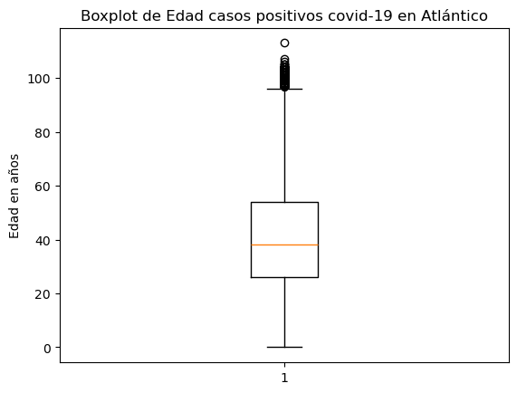

```python
plt.boxplot(df["Edad_años"])
plt.title("Boxplot de Edad casos positivos covid-19 en Atlántico")
plt.ylabel("Edad en años")
plt.show()
```

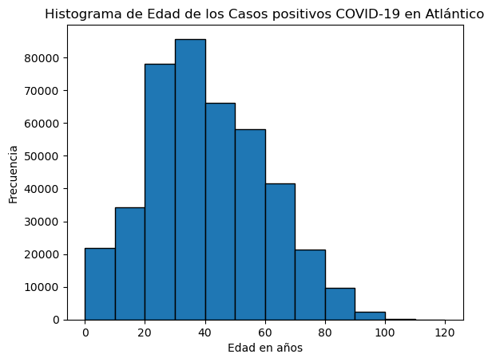

```python
plt.hist(df["Edad_años"], bins= np.arange(0, df["Edad_años"].max() + 10, 10), edgecolor="black")
plt.title("Histograma de Edad de los Casos positivos COVID-19 en Atlántico")
plt.xlabel("Edad en años")
plt.ylabel("Frecuencia")
plt.show()
```

A partir de las gráficas se puede observar que la mayor proporción de casos positivos de COVID-19 corresponde a personas con edades aproximadamente entre los 30 y 40 años.

```
C:\Users\Juanes Garcia Gomez\AppData\Local\Temp\ipykernel_18940\2507766175.py:1: UserWarning: Parsing dates in %d/%m/%Y %H:%M format when dayfirst=False (the default) was specified. Pass `dayfirst=True` or specify a format to silence this warning.
  df["Fecha de notificacion"] = pd.to_datetime(df["Fecha de notificacion"])
C:\Users\Juanes Garcia Gomez\AppData\Local\Temp\ipykernel_18940\2507766175.py:3: FutureWarning: 'M' is deprecated and will be removed in a future version, please use 'ME' instead.
  df.set_index("Fecha de notificacion")
```

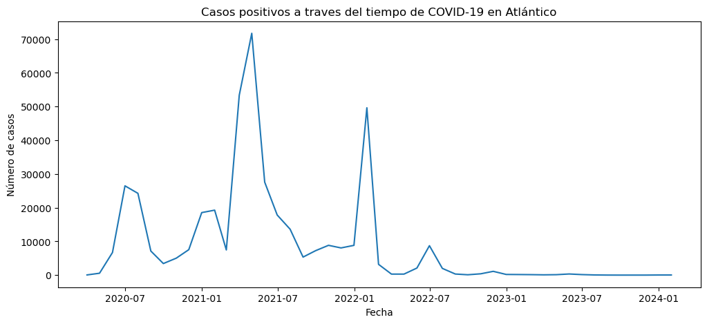

```python
df["Fecha de notificacion"] = pd.to_datetime(df["Fecha de notificacion"])
fecha_notificaciones = (
    df.set_index("Fecha de notificacion")
      .resample("M")
      .size()
)
plt.figure(figsize=(12,5))
plt.plot(fecha_notificaciones)
plt.title("Casos positivos a traves del tiempo de COVID-19 en Atlántico")
plt.xlabel("Fecha")
plt.ylabel("Número de casos")
plt.show()
```

```python
df["Fecha de notificacion"] = pd.to_datetime(df["Fecha de notificacion"])

tabla_casos = (
    df.groupby([
        df["Fecha de notificacion"].dt.year,
        df["Fecha de notificacion"].dt.month
    ])
    .size()
    .unstack(fill_value=0)
)

tabla_casos.columns = [
    "Enero","Febrero","Marzo","Abril","Mayo","Junio",
    "Julio","Agosto","Septiembre","Octubre","Noviembre","Diciembre"
]

tabla_casos
```

| Fecha de notificacion | Enero | Febrero | Marzo | Abril | Mayo | Junio | Julio | Agosto | Septiembre | Octubre | Noviembre | Diciembre |
| --- | --- | --- | --- | --- | --- | --- | --- | --- | --- | --- | --- | --- |
| 2020 | 0 | 0 | 71 | 575 | 6715 | 26486 | 24270 | 7155 | 3445 | 5045 | 7562 | 18555 |
| 2021 | 19279 | 7477 | 53350 | 71715 | 27589 | 17837 | 13620 | 5363 | 7261 | 8849 | 8080 | 8839 |
| 2022 | 49631 | 3209 | 316 | 318 | 2115 | 8740 | 2009 | 341 | 120 | 406 | 1136 | 214 |
| 2023 | 186 | 156 | 101 | 144 | 353 | 173 | 64 | 29 | 19 | 22 | 22 | 49 |
| 2024 | 50 | 0 | 0 | 0 | 0 | 0 | 0 | 0 | 0 | 0 | 0 | 0 |

Por lo observado en la grafica y en la tabla, hubo un pico de casos positivos durante Marzo y Abril 2021 en el que se obtuvieron 53,350 y 71,715 casos positivos de Covid 19 en el Atlantico. Tambien se puede observar que en el año 2023 se redujieron considerablemente los casos.

### Casos por Municipio:

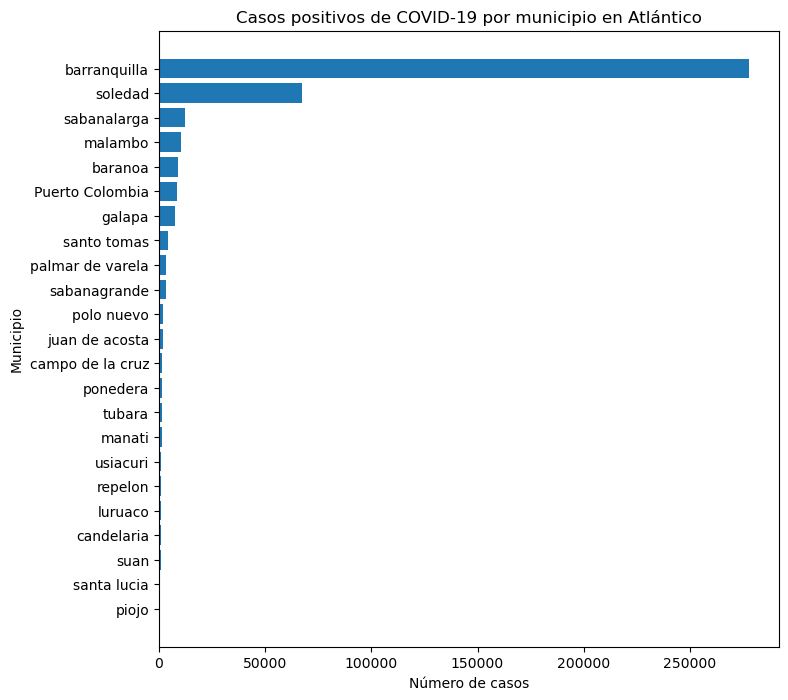

```python
casos_municipio = (
    df.groupby("Nombre municipio")
    .size()
    .sort_values(ascending=True)
)

plt.figure(figsize=(8,8))
plt.barh(casos_municipio.index, casos_municipio.values)
plt.title("Casos positivos de COVID-19 por municipio en Atlántico")
plt.xlabel("Número de casos")
plt.ylabel("Municipio")
plt.show()
```

A partir del grafico de Barras, se puede observar que la gran mayoria de los casos positvos de covid 19 se concentraron en Barranquilla ,seguido por Soledad y Sabanalarga. Mientras que los municipios menos afectados por la pandemia fueron Piojo, Santa Lucia y Suan.

## Tasa de mortalidad por municipio

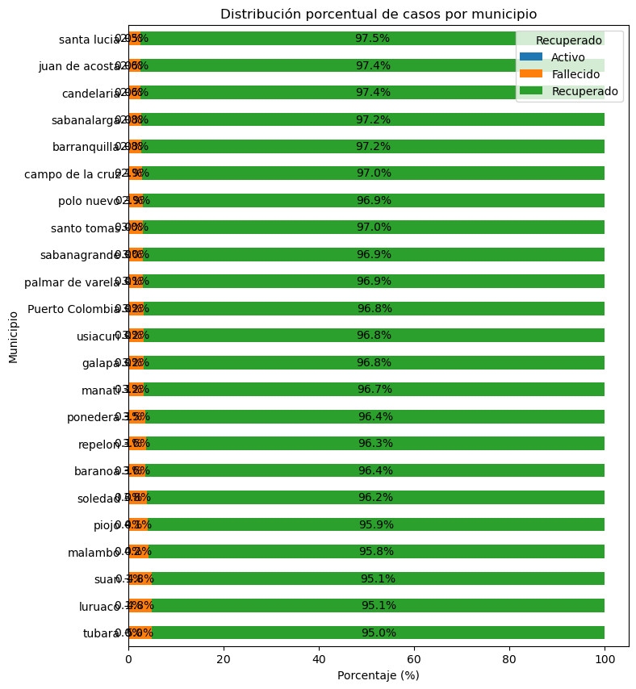

```python
tabla = pd.crosstab(
    df["Nombre municipio"],
    df["Recuperado"],
    normalize="index"
) * 100

tabla = tabla.sort_values(by="Fallecido", ascending=False)

ax = tabla.plot(
    kind="barh",
    stacked=True,
    figsize=(8,10)
)

plt.title("Distribución porcentual de casos por municipio")
plt.xlabel("Porcentaje (%)")
plt.ylabel("Municipio")

for container in ax.containers:
    ax.bar_label(container, fmt="%.1f%%", label_type="center")

plt.show()
```

A traves de esta grafica podemos observar que el municipio con mejor manejo en la pandemia fue Santa Lucia con un 97.5% de recuperados, teniendo en cuenta que fue el segundo municipio con menor casos de Covid 19 en el Atlantico. Juan de Acosta y Candelaria fueron los municipios por detras de Santa Lucia que tuvieron menor tasa de mortalidad ya que tuvieron un 97.4% de recuperados. Por otro lado, Tubara fue el mayor afectado en el Atlantico llegando a tener una tasa de mortalidad del 5% del Covid 19.

### Tipo de Contagio:

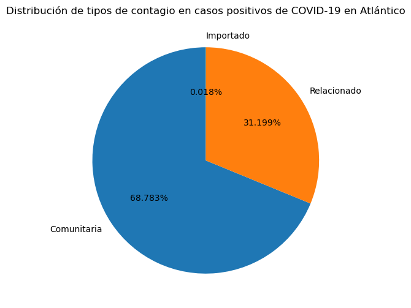

```python
plt.figure(figsize=(10, 6))
plt.pie(
    df["Tipo de contagio"].value_counts(),
    labels=df["Tipo de contagio"].value_counts().index,
    autopct="%1.3f%%",
    startangle=90
)
plt.title("Distribución de tipos de contagio en casos positivos de COVID-19 en Atlántico")
plt.show()
```

Con base en los resultados, el tipo de contagio mas comun es el comunitario con un 68%, es decir, cuando no se sabe la fuente exacta del contagio. La segunda forma de contagio mas frecuente es la "relacionada" con un 31%, en donde se sabe que hubo contacto directo con otra persona ya con el virus. Por ultimo, la menos comun es la "importada", y trata de los casos en donde se contagio en el extranjero y la vino despues al pais.

## Sexo:

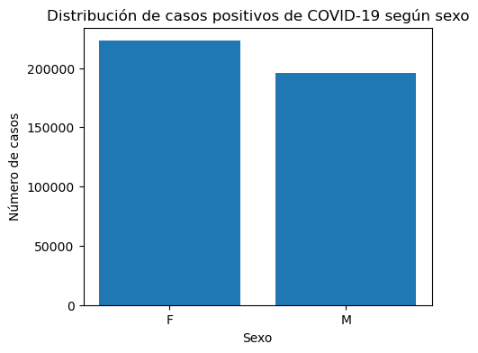

```python
sexo = df["Sexo"].value_counts()

plt.figure(figsize=(5,4))
plt.bar(sexo.index, sexo.values)
plt.title("Distribución de casos positivos de COVID-19 según sexo")
plt.xlabel("Sexo")
plt.ylabel("Número de casos")
plt.show()
```

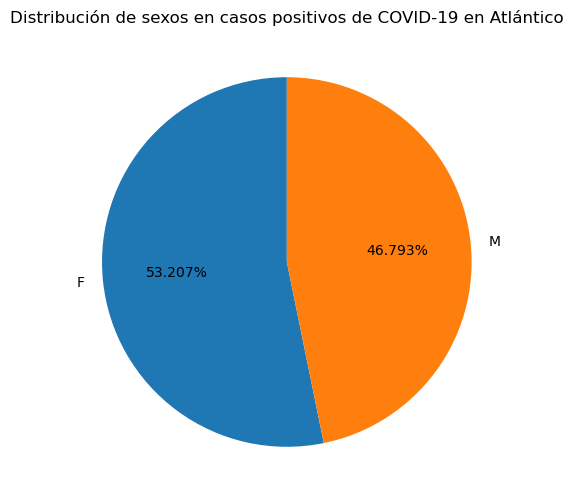

```python
plt.figure(figsize=(10, 6))
plt.pie(
    df["Sexo"].value_counts(),
    labels=df["Sexo"].value_counts().index,
    autopct="%1.3f%%",
    startangle=90
)
plt.title("Distribución de sexos en casos positivos de COVID-19 en Atlántico")
plt.show()
```

## Tasa de Mortalidad segun el sexo

[figure not shown]

```python
tabla = pd.crosstab(
    df["Sexo"],
    df["Recuperado"],
    normalize="index"
) * 100

tabla = tabla[["Fallecido", "Recuperado"]]

ax = tabla.plot(
    kind="bar",
    stacked=True,
    figsize=(6,4)
)

plt.title("Distribución porcentual de casos por municipio")
plt.xlabel("Porcentaje (%)")
plt.ylabel("Municipio")

for container in ax.containers:
    ax.bar_label(container, fmt="%.1f%%", label_type="center")

plt.show()
```

A partit del grafico de barras anterior, las mujeres en el atlantico son mas propensas a recuperarse del covid 19 en el Atlantico con una tasa de mortalidad del 2.5%. Mientras, que los hombres tienen una mayor tasa de deceso llegando al 3.7%.

## Recuperacion:

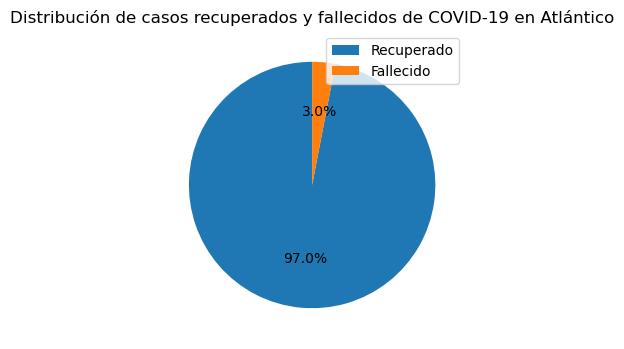

```python
df["Recuperado"] = df["Recuperado"].fillna("Fallecido")
Caso_recuperado = (
    df["Recuperado"]
    .value_counts()
    .loc[["Recuperado", "Fallecido"]]
)
plt.figure(figsize=(6,4))
plt.pie(
    Caso_recuperado.values,
    autopct="%1.1f%%",
    startangle=90
)
plt.legend(Caso_recuperado.index, loc="upper right")



plt.title("Distribución de casos recuperados y fallecidos de COVID-19 en Atlántico")
plt.show()
```

Segun el grafico circular, se puede observar que existe una tasa de mortalidad del 3% en los casos positivos del Covid 19 en el Atlantico. Mientras que el restante 97% corresponde a los recuperados.

## Dias de recuperacion

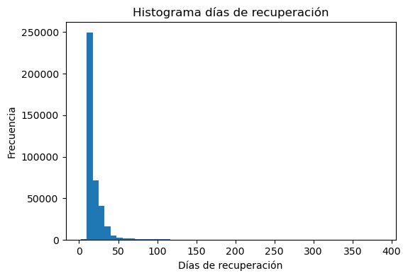

|  | Estadístico | Valor |
| --- | --- | --- |
| 0 | Número de casos | 403408.00 |
| 1 | Media | 23.23 |
| 2 | Desviación estándar | 28.58 |
| 3 | Mínimo | 2.00 |
| 4 | Percentil 25 (Q1) | 14.00 |
| 5 | Mediana (Q2) | 15.00 |
| 6 | Percentil 75 (Q3) | 21.00 |
| 7 | Máximo | 386.00 |

```python
plt.figure(figsize=(6,4))
plt.hist(df["Dias de recuperacion"], bins=50)
plt.xlabel("Días de recuperación")
plt.ylabel("Frecuencia")
plt.title("Histograma días de recuperación")
plt.show()


stats = df["Dias de recuperacion"].describe()

tabla_dias_de_recuperacion = pd.DataFrame({
    "Estadístico": [
        "Número de casos",
        "Media",
        "Desviación estándar",
        "Mínimo",
        "Percentil 25 (Q1)",
        "Mediana (Q2)",
        "Percentil 75 (Q3)",
        "Máximo"
    ],
    "Valor": [
        int(stats["count"]),
        round(stats["mean"], 2),
        round(stats["std"], 2),
        int(stats["min"]),
        int(stats["25%"]),
        int(stats["50%"]),
        int(stats["75%"]),
        int(stats["max"])
    ]
})

tabla_dias_de_recuperacion
```

En este Grafico del histograma se puede analizar que existe una distribucion asimetrica con un gran sesgo hacia la derecha. En la tabla se puede observar que el 50% de los datos de las personas para recuperarse del covid 19 ronda entre los 14 y 21 dias. la media de dias de recuperacion es de 23 dias por lo que esta fuera de este rango intercuartilico debido a la gran dispersion de datos por la cola larga en la derecha, ya que existen pacientes con recuperacion de hasta 386 dias. En este caso la mejor medida tendencia central es la mediana con un valor de 15 dias al presentar mejor comportamiento tipico que la media

## Dias hasta Fallecimiento de pacientes con covid 19

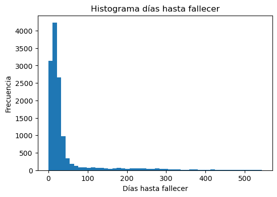

|  | Estadístico | Valor |
| --- | --- | --- |
| 0 | Número de casos | 13130.00 |
| 1 | Media | 42.41 |
| 2 | Desviación estándar | 74.91 |
| 3 | Mínimo | 0.00 |
| 4 | Percentil 25 (Q1) | 11.00 |
| 5 | Mediana (Q2) | 19.00 |
| 6 | Percentil 75 (Q3) | 31.00 |
| 7 | Máximo | 543.00 |

```python
plt.figure(figsize=(6,4))
plt.hist(df["dias hasta fallecimiento"], bins=50)
plt.xlabel("Días hasta fallecer")
plt.ylabel("Frecuencia")
plt.title("Histograma días hasta fallecer")
plt.show()


stats = df["dias hasta fallecimiento"].describe()

tabla_dias_hasta_fallecer = pd.DataFrame({
    "Estadístico": [
        "Número de casos",
        "Media",
        "Desviación estándar",
        "Mínimo",
        "Percentil 25 (Q1)",
        "Mediana (Q2)",
        "Percentil 75 (Q3)",
        "Máximo"
    ],
    "Valor": [
        int(stats["count"]),
        round(stats["mean"], 2),
        round(stats["std"], 2),
        int(stats["min"]),
        int(stats["25%"]),
        int(stats["50%"]),
        int(stats["75%"]),
        int(stats["max"])
    ]
})

tabla_dias_hasta_fallecer
```

Asi como el anterior analisis, la distribución de días hasta fallecer presenta una fuerte asimetría positiva , con la mayoría de los casos concentrados entre 11 y 31 días .La media es mucho mayor que la mediana debido a valores atipicos en la cola de la derecha que alcanzan hasta 543 días. Entonces, se toma la mediana como la mejor medida central debido a que presenta un mejor comportamiento tipico teniendo un valor de 19 dias.

## Correlacion entre variables numericas

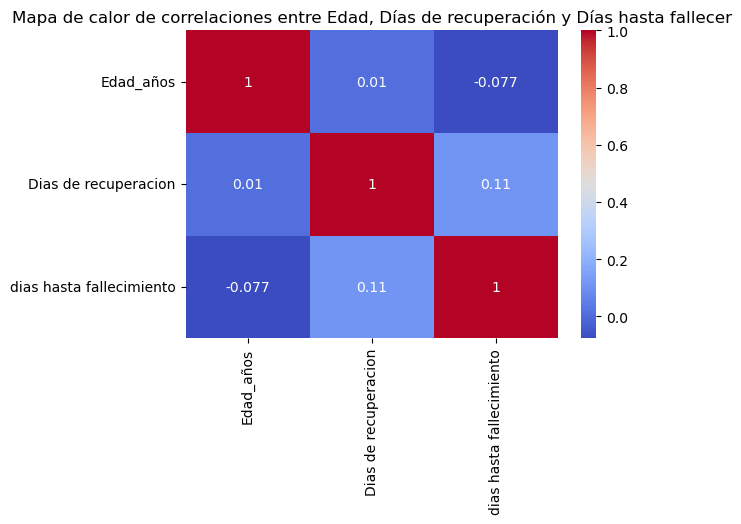

```python
plt.figure(figsize=(6,4))
sns.heatmap(df[["Edad_años", "Dias de recuperacion", "dias hasta fallecimiento"]].corr(method="spearman"), annot=True, cmap="coolwarm")
plt.title("Mapa de calor de correlaciones entre Edad, Días de recuperación y Días hasta fallecer")
plt.show()
```

La matriz de correlacion entre las variables cuantitativas como lo son los dias hasta el fallecimiento, dias de recuperacion y edad muestra que no existe correlacion alguna entre estas. El objetivo principal de este grafico era verificar si el factor de la edad influye en el tiempo que toma una persona infectada por covid 19 en recuperarse o en el tiempo hasta fallecer.

## Conclusion

El análisis exploratorio de datos evidenció una gran cantidad considerable de valores faltantes en algunas variables, por lo que se requirio realizar procesos de limpieza y transformación para evitar datos erroneos en la información. A partir del tratamiento de las fechas, se generaron nuevas variables como los días de recuperación y los días hasta el fallecimiento, lo que permitió un análisis más detallado del comportamiento de la pandemia en el tiempo y ayudar a identificar de los picos de casos positivos.

Además, se obtuvo información relevante sobre la distribución de los casos y la tasa de mortalidad según sexo y municipio, analizando cuáles fueron los territorios más afectados y los que mejor respondieron frente al virus. Los gráficos facilitaron la interpretación de tendencias y el impacto en la población del Atlántico según edad, sexo y ubicación, clarificando información útil para la toma de decisiones y la preparación para futuras emergencias sanitarias.